# Vignette 1: Method Validation with Synthetic Data (DUMMY4)

## Overview

This vignette validates the core **geomix** unmixing workflow using the **DUMMY4** synthetic dataset, where true mixing proportions (**A**) and true source signatures (**B**) are fully known. Because ground truth is available, recovery accuracy can be measured directly with mean absolute error (MAE).

**Dataset:** 15 artificial mixtures (MIX1–MIX15) of three end-members (K = 3) across two complementary proxy blocks:

| Block | Type | Description |
| --- | --- | --- |
| **DZ** | Distributional (KDE) | Detrital zircon: 7 geochemical proxies per grain |
| **BP** | Compositional (simplex) | Bulk petrography: 5 mineral fractions per sample |

The two blocks intentionally sample different grain-size fractions of the sedimentary load, providing complementary provenance signals.

**Six methods are benchmarked:**

1. **Baseline** — NNLS in simplex space, joint blocks, `inv_f` weighting
2. **Entropy + inv_f** — same, with sample-adaptive entropy weighting
3. **DZ only** — single-block NNLS on distributional data
4. **BP only** — single-block NNLS on compositional data
5. **CLR + NNLS** — both blocks CLR-transformed, NNLS solver
6. **CLR + OLS** — both blocks CLR-transformed, OLS solver

Methods 5–6 serve as foils: the CLR transformation breaks the linear mixing structure that holds in simplex space, and the benchmark quantifies the resulting loss in recovery accuracy.

```r
library(geomix)
library(dplyr)
library(tidyr)
library(tibble)
library(ggplot2)
library(clue)
library(scales)
library(compositions)
```

## 1. Load data

```r
data("DUMMY4_DZ")        # grain-level DZ measurements  (long format)
data("DUMMY4_grainsize") # grain-level petrography      (long format)
data("DUMMY4_EM")        # end-member raw data          (same formats)
data("DUMMY4_A_true")    # known mixing proportions     (ground truth)

K        <- 3L
N_POINTS <- 129L
```

## 2. Build data matrices

KDE normalisation uses `y / sum(y)` (sum = 1 per variable), which preserves the absolute scale difference between blocks that `inv_f` global weighting relies on. A global bandwidth (pooled across all samples) and a common evaluation grid are used per variable, matching the validation script exactly.

```r
dz_vars <- setdiff(names(DUMMY4_DZ), "sample")
samples <- sort(unique(DUMMY4_DZ$sample))

# ---- local KDE helpers (matching validation script) -------------------------

get_evalpoints <- function(x, n = 129, probs = c(0.03, 0.97)) {
  x <- x[is.finite(x)]
  if (length(x) < 2) return(seq(0, 1, length.out = n))
  q <- quantile(x, probs = probs, na.rm = TRUE)
  seq(q[1], q[2], length.out = n)
}

default_bandwidth <- function(x) {
  x <- x[is.finite(x)]
  if (length(x) < 2) return(1)
  bw <- tryCatch(bw.SJ(x, method = "ste"), error = function(e) bw.nrd0(x))
  if (!is.finite(bw) || bw <= 0) bw <- 1
  bw
}

discretize_kde <- function(x, evalpoints, bw = NULL) {
  x <- x[is.finite(x)]
  if (length(x) < 2) return(rep(0, length(evalpoints)))
  if (is.null(bw)) bw <- default_bandwidth(x)
  dens <- density(x, bw = bw, from = min(evalpoints),
                  to = max(evalpoints), n = length(evalpoints))
  dens$y
}

# ---- DZ matrix: KDE normalised to sum = 1 per variable ----------------------
x_grids <- lapply(dz_vars, function(v)
  get_evalpoints(as.numeric(DUMMY4_DZ[[v]]), N_POINTS))
names(x_grids) <- dz_vars

DZ_mat <- matrix(0, length(samples), length(dz_vars) * N_POINTS,
                 dimnames = list(samples, NULL))

for (i in seq_along(samples)) {
  samp_data <- DUMMY4_DZ[DUMMY4_DZ$sample == samples[i], ]
  row_vec <- c()
  for (v in dz_vars) {
    bw_global <- default_bandwidth(as.numeric(DUMMY4_DZ[[v]]))
    vals      <- as.numeric(samp_data[[v]])
    y         <- discretize_kde(vals, x_grids[[v]], bw = bw_global)
    y         <- y / max(sum(y), 1e-10)
    row_vec   <- c(row_vec, y)
  }
  DZ_mat[i, ] <- row_vec
}

# ---- BP matrix: simplex with Laplace smoothing ------------------------------
BP_counts <- DUMMY4_grainsize %>%
  group_by(sample, name) %>%
  summarise(n = n(), .groups = "drop") %>%
  pivot_wider(names_from = name, values_from = n, values_fill = 0) %>%
  arrange(match(sample, samples))

minerals <- setdiff(names(BP_counts), "sample")
BP_raw   <- as.matrix(BP_counts[, minerals])
BP_mat   <- (BP_raw + 1e-6) / rowSums(BP_raw + 1e-6)
rownames(BP_mat) <- samples

stopifnot(identical(rownames(DZ_mat), rownames(BP_mat)))

cat(sprintf("DZ : %d samples x %d features (%d vars x %d pts)\n",
            nrow(DZ_mat), ncol(DZ_mat), length(dz_vars), N_POINTS))
```

```
#> DZ : 15 samples x 903 features (7 vars x 129 pts)
```

```r
cat(sprintf("BP : %d samples x %d components [%s]\n",
            nrow(BP_mat), ncol(BP_mat), paste(minerals, collapse = ", ")))
```

```
#> BP : 15 samples x 5 components [Carbonate, Clay-Mineral, Feldspar, Lithic, Quartz]
```

## 3. Build end-member reference matrices (B ground truth)

```r
em_ids <- sort(unique(DUMMY4_EM$sample))

# B_true DZ: same KDE preprocessing as mixtures
B_true_dz <- matrix(0, length(em_ids), length(dz_vars) * N_POINTS,
                    dimnames = list(em_ids, NULL))

for (i in seq_along(em_ids)) {
  em_data <- DUMMY4_EM[DUMMY4_EM$sample == em_ids[i], ]
  row_vec <- c()
  for (v in dz_vars) {
    all_vals_v <- as.numeric(DUMMY4_EM$value[DUMMY4_EM$name == v])
    bw_v  <- default_bandwidth(all_vals_v)
    vals  <- as.numeric(em_data$value[em_data$name == v])
    y     <- discretize_kde(vals, x_grids[[v]], bw = bw_v)
    y     <- y / max(sum(y), 1e-10)
    row_vec <- c(row_vec, y)
  }
  B_true_dz[i, ] <- row_vec
}

# B_true BP: simplex with Laplace smoothing
bp_em_counts <- DUMMY4_EM %>%
  filter(name %in% minerals) %>%
  group_by(sample, name) %>%
  summarise(n = n(), .groups = "drop") %>%
  pivot_wider(names_from = name, values_from = n, values_fill = 0) %>%
  arrange(match(sample, em_ids))

B_true_bp_raw <- as.matrix(bp_em_counts[, minerals])
B_true_bp     <- (B_true_bp_raw + 1e-6) / rowSums(B_true_bp_raw + 1e-6)
rownames(B_true_bp) <- em_ids

cat("B_true_dz:", nrow(B_true_dz), "x", ncol(B_true_dz), "\n")
```

```
#> B_true_dz: 3 x 903
```

```r
cat("B_true_bp:\n"); print(round(B_true_bp, 3))
```

```
#> B_true_bp:
#>     Carbonate Clay-Mineral Feldspar Lithic Quartz
#> em1     0.138        0.103    0.241  0.069  0.448
#> em2     0.109        0.091    0.473  0.109  0.218
#> em3     0.173        0.135    0.154  0.154  0.385
```

## 4. True mixing proportions (A_true)

```r
A_true <- DUMMY4_A_true %>%
  filter(sample %in% samples) %>%
  arrange(match(sample, samples)) %>%
  select(-sample) %>%
  as.matrix()
rownames(A_true) <- samples
colnames(A_true) <- paste0("EM", 1:K)
```

## 5. Run unmixing — six methods

```r
clr_rows <- function(M, eps = 1e-6) {
  M[M <= 0] <- eps
  M <- M / rowSums(M)
  as.matrix(compositions::clr(compositions::acomp(M)))
}

DZ_clr <- clr_rows(DZ_mat)
BP_clr <- clr_rows(BP_mat)

run <- function(...) {
  fit <- unmix(...)
  rownames(fit$A) <- samples
  fit
}

# 1. Baseline: NNLS simplex, joint, inv_f
fit_base <- run(
  data_list  = list(DZ = DZ_mat, BP = BP_mat),
  data_types = c(DZ = "continuous", BP = "simplex"),
  K = K, weighting = "inv_f", adaptive = "none",
  normalize_blocks = "by_col",
  max_iter = 5000, tol = 1e-8, eta_A = 0.5, seed = 1
)

# 2. Entropy + inv_f
fit_ent <- run(
  data_list  = list(DZ = DZ_mat, BP = BP_mat),
  data_types = c(DZ = "continuous", BP = "simplex"),
  K = K, weighting = "inv_f", adaptive = "entropy",
  normalize_blocks = "by_col",
  max_iter = 5000, tol = 1e-8, eta_A = 0.5, seed = 1
)

# 3. DZ only
fit_dz <- run(
  data_list  = list(DZ = DZ_mat),
  data_types = c(DZ = "continuous"),
  K = K, weighting = "none", adaptive = "none",
  normalize_blocks = "by_col",
  max_iter = 5000, tol = 1e-8, eta_A = 0.5, seed = 1
)

# 4. BP only
fit_bp <- run(
  data_list  = list(BP = BP_mat),
  data_types = c(BP = "simplex"),
  K = K, weighting = "none", adaptive = "none",
  normalize_blocks = "by_col",
  max_iter = 10000, tol = 1e-8, eta_A = 0.5, seed = 1
)

# 5. CLR + NNLS (no by_col — already in symmetric CLR space)
fit_clr_nnls <- run(
  data_list  = list(DZ = DZ_clr, BP = BP_clr),
  data_types = c(DZ = "clr", BP = "clr"),
  K = K, weighting = "none", adaptive = "none",
  normalize_blocks = "none",
  method = "nnls", max_iter = 5000, tol = 1e-8, eta_A = 0.5, seed = 1
)

# 6. CLR + OLS
fit_clr_ols <- run(
  data_list  = list(DZ = DZ_clr, BP = BP_clr),
  data_types = c(DZ = "clr", BP = "clr"),
  K = K, weighting = "none", adaptive = "none",
  normalize_blocks = "none",
  method = "ols", max_iter = 5000, tol = 1e-8, eta_A = 0.5, seed = 2
)
```

## 6. Align end-members to ground truth

End-members are permuted using the Hungarian algorithm applied to Hellinger distances between estimated and true DZ signatures (B₁). For BP-only fits, alignment uses MAE on mineral proportions (B₂). For CLR fits, B is back-transformed to simplex before alignment.

```r
hellinger <- function(p, q) {
  p[!is.finite(p)] <- 0
  q[!is.finite(q)] <- 0
  s_p <- sum(p); s_q <- sum(q)
  if (s_p <= 0 || s_q <= 0) return(1)   # máxima distância se KDE vazia
  p <- p / s_p
  q <- q / s_q
  sqrt(0.5 * sum((sqrt(p) - sqrt(q))^2))
}

align_via_B1 <- function(A_est, B1_est, B_true_dz, dz_vars, n_pts, A_true) {
  K_loc <- ncol(A_true)
  cost  <- matrix(0, K_loc, K_loc)
  for (h in seq_len(K_loc)) {
    for (k in seq_len(K_loc)) {
      d <- 0
      for (vi in seq_along(dz_vars)) {
        cols   <- ((vi - 1) * n_pts + 1):(vi * n_pts)
        d      <- d + hellinger(B_true_dz[h, cols], B1_est[k, cols])
      }
      cost[h, k] <- d / length(dz_vars)
    }
  }
  perm  <- as.integer(clue::solve_LSAP(cost))
  A_out <- A_est[, perm, drop = FALSE]
  colnames(A_out) <- colnames(A_true)
  list(A = A_out, perm = perm)
}

align_via_B2 <- function(A_est, B2_est, B_true_bp, A_true) {
  K_loc <- ncol(A_true)
  cost  <- matrix(0, K_loc, K_loc)
  for (h in seq_len(K_loc)) for (k in seq_len(K_loc))
    cost[h, k] <- mean(abs(B_true_bp[h, ] - B2_est[k, ]))
  perm  <- as.integer(clue::solve_LSAP(cost))
  A_out <- A_est[, perm, drop = FALSE]
  colnames(A_out) <- colnames(A_true)
  list(A = A_out, perm = perm)
}

clr_to_simplex <- function(M) {
  out <- t(apply(M, 1, function(r) as.numeric(compositions::clrInv(r))))
  out / rowSums(out)
}

al_base     <- align_via_B1(fit_base$A,     fit_base$B_list[["DZ"]],
                             B_true_dz, dz_vars, N_POINTS, A_true)
al_ent      <- align_via_B1(fit_ent$A,      fit_ent$B_list[["DZ"]],
                             B_true_dz, dz_vars, N_POINTS, A_true)
al_dz       <- align_via_B1(fit_dz$A,       fit_dz$B_list[["DZ"]],
                             B_true_dz, dz_vars, N_POINTS, A_true)
al_bp       <- align_via_B2(fit_bp$A,       fit_bp$B_list[["BP"]],
                             B_true_bp, A_true)
al_clr_nnls <- align_via_B1(fit_clr_nnls$A,
                             clr_to_simplex(fit_clr_nnls$B_list[["DZ"]]),
                             B_true_dz, dz_vars, N_POINTS, A_true)
al_clr_ols  <- align_via_B1(fit_clr_ols$A,
                             clr_to_simplex(fit_clr_ols$B_list[["DZ"]]),
                             B_true_dz, dz_vars, N_POINTS, A_true)

A_base     <- al_base$A
A_ent      <- al_ent$A
A_dz       <- al_dz$A
A_bp       <- al_bp$A
A_clr_nnls <- al_clr_nnls$A
A_clr_ols  <- al_clr_ols$A

mae <- function(e, t) mean(abs(e - t))
r2  <- function(e, t) cor(as.vector(t), as.vector(e))^2
```

## 7. Accuracy table

```r
method_levels <- c("Baseline", "Entropy + inv_f", "DZ only",
                   "BP only",  "CLR + NNLS",      "CLR + OLS")

results <- tibble(
  Method    = method_levels,
  MAE       = c(mae(A_base, A_true), mae(A_ent,      A_true),
                mae(A_dz,  A_true),  mae(A_bp,       A_true),
                mae(A_clr_nnls, A_true), mae(A_clr_ols, A_true)),
  R2        = c(r2(A_base, A_true),  r2(A_ent,       A_true),
                r2(A_dz,   A_true),  r2(A_bp,        A_true),
                r2(A_clr_nnls, A_true),  r2(A_clr_ols, A_true)),
  Converged = c(fit_base$converged,  fit_ent$converged,
                fit_dz$converged,    fit_bp$converged,
                fit_clr_nnls$converged, fit_clr_ols$converged),
  Iters     = c(fit_base$iters,      fit_ent$iters,
                fit_dz$iters,        fit_bp$iters,
                fit_clr_nnls$iters,  fit_clr_ols$iters)
) %>%
  arrange(MAE) %>%
  mutate(MAE = round(MAE, 4), R2 = round(R2, 3))

knitr::kable(results,
             caption = "Recovery accuracy: MAE and R² between estimated and true A")
```

Recovery accuracy: MAE and R² between estimated and true A

| Method | MAE | R2 | Converged | Iters |
| --- | --- | --- | --- | --- |
| BP only | 0.0833 | 0.854 | TRUE | 9495 |
| DZ only | 0.0888 | 0.972 | TRUE | 186 |
| Baseline | 0.0893 | 0.976 | TRUE | 267 |
| Entropy + inv_f | 0.0911 | 0.975 | TRUE | 167 |
| CLR + NNLS | 0.1004 | 0.954 | TRUE | 25 |
| CLR + OLS | 0.2994 | 0.043 | TRUE | 327 |

## 8. Estimated vs. true proportions (scatter)

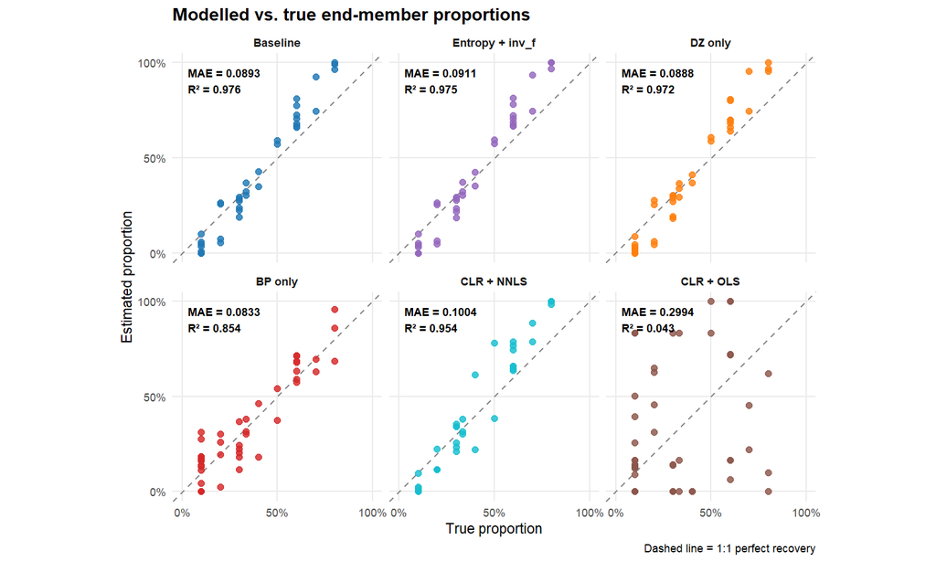

```r
pal <- c(
  "Baseline"       = "#1f77b4",
  "Entropy + inv_f"= "#9467bd",
  "DZ only"        = "#ff7f0e",
  "BP only"        = "#d62728",
  "CLR + NNLS"     = "#17becf",
  "CLR + OLS"      = "#8c564b"
)

scatter_df <- bind_rows(
  tibble(true = as.vector(A_true), est = as.vector(A_base),     method = "Baseline"),
  tibble(true = as.vector(A_true), est = as.vector(A_ent),      method = "Entropy + inv_f"),
  tibble(true = as.vector(A_true), est = as.vector(A_dz),       method = "DZ only"),
  tibble(true = as.vector(A_true), est = as.vector(A_bp),       method = "BP only"),
  tibble(true = as.vector(A_true), est = as.vector(A_clr_nnls), method = "CLR + NNLS"),
  tibble(true = as.vector(A_true), est = as.vector(A_clr_ols),  method = "CLR + OLS")
) %>%
  mutate(method = factor(method, levels = method_levels))

mae_labels <- results %>%
  mutate(method = factor(Method, levels = method_levels),
         label  = sprintf("MAE = %.4f\nR\u00b2 = %.3f", MAE, R2))

ggplot(scatter_df, aes(x = true, y = est)) +
  geom_abline(slope = 1, intercept = 0,
              linetype = "dashed", colour = "grey55", linewidth = 0.55) +
  geom_point(aes(colour = method), size = 2.2, alpha = 0.82) +
  geom_text(data    = mae_labels,
            mapping = aes(x = 0.03, y = 0.97, label = label),
            hjust = 0, vjust = 1, size = 3.0, fontface = "bold",
            inherit.aes = FALSE) +
  facet_wrap(~ method, nrow = 2) +
  scale_x_continuous(limits = c(0, 1), labels = percent_format(1),
                     breaks = c(0, 0.5, 1)) +
  scale_y_continuous(limits = c(0, 1), labels = percent_format(1),
                     breaks = c(0, 0.5, 1)) +
  scale_colour_manual(values = pal) +
  labs(x       = "True proportion",
       y       = "Estimated proportion",
       title   = "Modelled vs. true end-member proportions",
       caption = "Dashed line = 1:1 perfect recovery") +
  theme_minimal(base_size = 11) +
  theme(legend.position  = "none",
        strip.text       = element_text(face = "bold"),
        panel.grid.minor = element_blank(),
        plot.title       = element_text(face = "bold")) +
  coord_fixed()
```

## 9. Per-sample mixing proportions (bar chart)

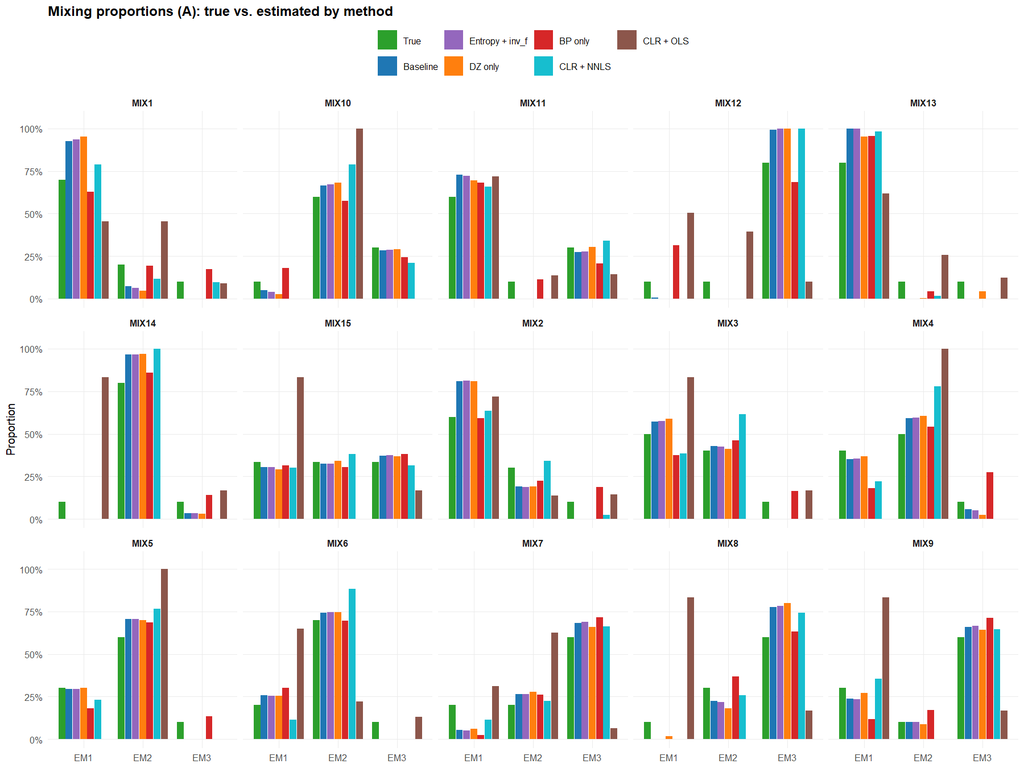

```r
build_A_long <- function(A, type) {
  as.data.frame(A) %>%
    rownames_to_column("sample") %>%
    pivot_longer(-sample, names_to = "source", values_to = "value") %>%
    mutate(type = type)
}

A_long <- bind_rows(
  build_A_long(A_true,     "True"),
  build_A_long(A_base,     "Baseline"),
  build_A_long(A_ent,      "Entropy + inv_f"),
  build_A_long(A_dz,       "DZ only"),
  build_A_long(A_bp,       "BP only"),
  build_A_long(A_clr_nnls, "CLR + NNLS"),
  build_A_long(A_clr_ols,  "CLR + OLS")
) %>%
  mutate(
    sample = factor(sample, levels = samples),
    type   = factor(type, levels = c("True", method_levels))
  )

pal_full <- c("True" = "#2ca02c", pal)

ggplot(A_long, aes(x = source, y = value, fill = type)) +
  geom_col(position = position_dodge(0.85), width = 0.8) +
  facet_wrap(~ sample, ncol = 5) +
  scale_y_continuous(labels = percent_format(1), limits = c(0, 1.05)) +
  scale_fill_manual(values = pal_full, name = NULL) +
  labs(x = NULL, y = "Proportion",
       title = "Mixing proportions (A): true vs. estimated by method") +
  theme_minimal(base_size = 9.5) +
  theme(legend.position  = "top",
        strip.text       = element_text(face = "bold"),
        panel.grid.minor = element_blank(),
        plot.title       = element_text(face = "bold"),
        axis.text.x      = element_text(size = 7.5))
```

## 10. DZ source signatures (B₁)

Estimated KDE distributions for the three end-members from the Baseline fit, compared to the known true signatures. Rows = end-members (EM1–EM3), columns = geochemical proxies.

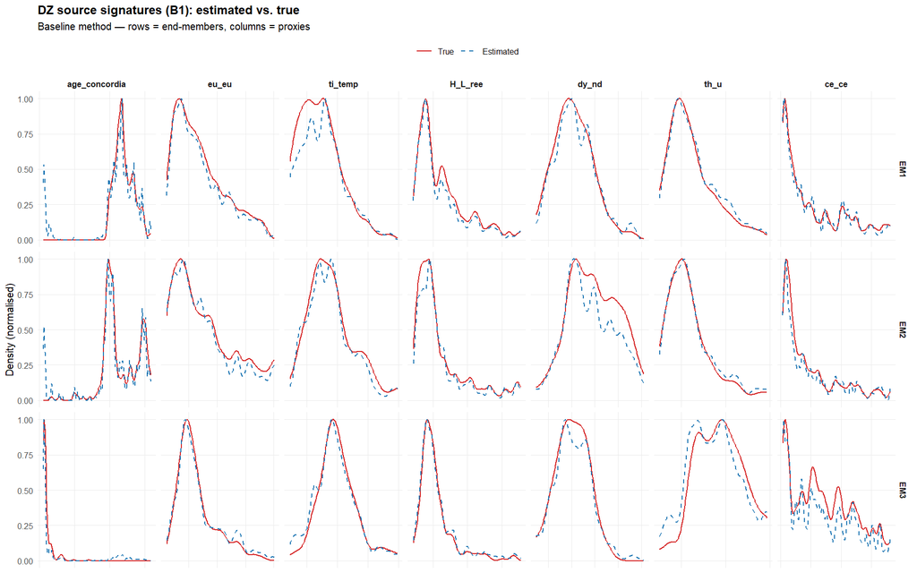

```r
perm_base  <- al_base$perm
B1_est     <- fit_base$B_list[["DZ"]]
B1_aligned <- B1_est[perm_base, , drop = FALSE]

B1_df <- bind_rows(lapply(seq_along(dz_vars), function(vi) {
  v    <- dz_vars[vi]
  grid <- x_grids[[v]]
  cols <- ((vi - 1) * N_POINTS + 1):(vi * N_POINTS)
  bind_rows(lapply(1:K, function(h) {
    y_t <- B_true_dz[h, cols];  y_t <- y_t / max(max(y_t), 1e-10)
    y_e <- B1_aligned[h, cols]; y_e <- y_e / max(max(y_e), 1e-10)
    bind_rows(
      tibble(x = grid, y = y_t, EM = paste0("EM", h), var = v, type = "True"),
      tibble(x = grid, y = y_e, EM = paste0("EM", h), var = v, type = "Estimated")
    )
  }))
})) %>%
  mutate(EM   = factor(EM,  levels = paste0("EM", 1:K)),
         var  = factor(var, levels = dz_vars),
         type = factor(type, levels = c("True", "Estimated")))

ggplot(B1_df, aes(x = x, y = y, colour = type, linetype = type)) +
  geom_line(linewidth = 0.65) +
  facet_grid(EM ~ var, scales = "free_x") +
  scale_colour_manual(values = c(True = "#d62728", Estimated = "#1f77b4"),
                      name = NULL) +
  scale_linetype_manual(values = c(True = "solid", Estimated = "dashed"),
                        name = NULL) +
  labs(x = NULL, y = "Density (normalised)",
       title    = "DZ source signatures (B1): estimated vs. true",
       subtitle = "Baseline method — rows = end-members, columns = proxies") +
  theme_minimal(base_size = 9.5) +
  theme(legend.position  = "top",
        strip.text.x     = element_text(face = "bold", size = 8),
        strip.text.y     = element_text(face = "bold"),
        panel.grid.minor = element_blank(),
        axis.text.x      = element_blank(),
        axis.ticks.x     = element_blank(),
        plot.title       = element_text(face = "bold"))
```

## 11. BP source compositions (B₂)

Estimated mineral proportions for the three end-members from the Baseline fit, compared to the true simplex compositions.

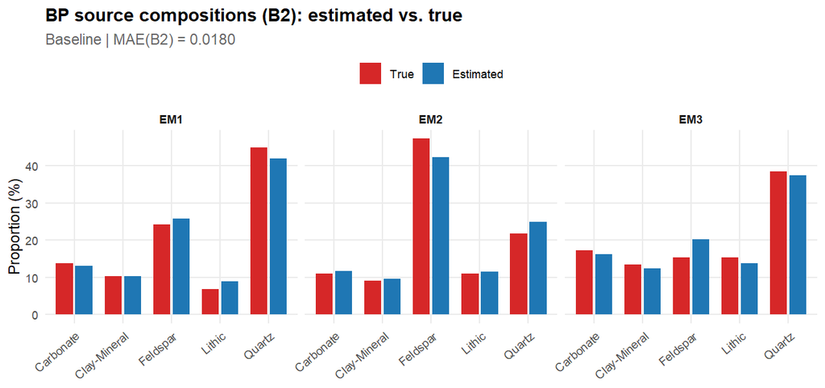

```r
B2_est     <- fit_base$B_list[["BP"]]
colnames(B2_est) <- minerals
B2_aligned <- B2_est[perm_base, , drop = FALSE]

B2_df <- bind_rows(
  as.data.frame(B_true_bp) %>%
    mutate(EM = paste0("EM", 1:K)) %>%
    pivot_longer(-EM, names_to = "mineral", values_to = "prop") %>%
    mutate(type = "True"),
  as.data.frame(B2_aligned) %>%
    mutate(EM = paste0("EM", 1:K)) %>%
    pivot_longer(-EM, names_to = "mineral", values_to = "prop") %>%
    mutate(type = "Estimated")
) %>%
  mutate(EM      = factor(EM,      levels = paste0("EM", 1:K)),
         mineral = factor(mineral, levels = minerals),
         type    = factor(type,    levels = c("True", "Estimated")))

mae_B2 <- B2_df %>%
  pivot_wider(names_from = type, values_from = prop) %>%
  summarise(mae = mean(abs(True - Estimated), na.rm = TRUE)) %>%
  pull(mae)

ggplot(B2_df, aes(x = mineral, y = prop * 100, fill = type)) +
  geom_col(position = position_dodge(0.8), width = 0.7) +
  facet_wrap(~ EM, nrow = 1) +
  scale_fill_manual(values = c(True = "#d62728", Estimated = "#1f77b4"),
                    name = NULL) +
  labs(x = NULL, y = "Proportion (%)",
       title    = "BP source compositions (B2): estimated vs. true",
       subtitle = sprintf("Baseline | MAE(B2) = %.4f", mae_B2)) +
  theme_minimal(base_size = 11) +
  theme(legend.position  = "top",
        axis.text.x      = element_text(angle = 40, hjust = 1),
        strip.text       = element_text(face = "bold"),
        panel.grid.minor = element_blank(),
        plot.title       = element_text(face = "bold"),
        plot.subtitle    = element_text(colour = "grey40"))
```

## 12. Key results

The benchmark confirms the following properties of the geomix unmixing framework:

**Simplex vs. CLR:** CLR-transformed methods (CLR + NNLS, CLR + OLS) yield substantially higher MAE than their simplex-space counterparts. This is consistent with the theoretical incompatibility of CLR transformation with linear mixing: mixing is linear in simplex space, but the CLR map is non-linear with respect to mixing proportions, so NMF-style alternating solvers converge to systematically biased solutions.

**Adaptive weighting:** Entropy + inv_f does not outperform the Baseline on DUMMY4. This is expected — entropy weighting helps most when samples vary strongly in how well each block constrains the unmixing, which is not the case in this uniform synthetic dataset.